# Using the sum-matched Metropolis-Hastings algorithm in R

Timo Bechger & Gunter Maris

2021-02-15

This is a supplement to Chapter 7 in **Computational Psychometrics**. It aims to provide examples showing how the **Sum-Matched Metropolis-Hastings (SM-MH) algorithm** can be used in a plug-and-play way to develop Gibbs samplers for logistic regression and **item response theory (IRT) models** - some common, some new. For didactic purposes, we have programmed everything in native R code so that this vignette can be read independently of our **jabs** package. The package implements the same functions in a more efficient way. References can be found in the chapter.

# The SM-HM algorithm

The SM-MH algorithm is a procedure to sample efficiently from a posterior distribution of the form:
$$\begin{align}
f(\eta|\mathbf{x})
&\propto f(\eta,\mathbf{x}) = \prod^{n}_{i=1} F_i(\eta)^{x_i}
\left(1-F_i(\eta)\right)^{1-x_i} f(\eta),
\end{align}$$
where $\mathbf{x}$ is a vector of binary observations, $f(\eta)$ is a prior density, and
$$F_i(\eta)=P(X_i=1|\eta, a_i, b_i)=\frac{\exp(a_i \eta +b_i)}{1+\exp(a_i \eta +b_i)}$$
is a logistic cumulative distribution function (cdf) with location $-b_i a^{-1}_i$ and (positive) scale parameter $a^{-1}_i$. Note that the posterior depends on the observations only via the sufficient statistic $\sum^{n}_{i=1} a_i x_i$.

At least to psychometricians, the notation suggests that we consider a **two-parameter logistic (2PL) model** with $\eta$ a student ability, $b_i$ item difficulty and $a_i$ item discrimination, and wish to produce do-called **plausible values**; that is, a sample from the posterior of ability given known item parameters. This is but one instance of the general problem, however. In the sequel, $\eta$ represent a parameter of interest and $a$ and $b$ will be constants that encode knowledge of other parameters in the model.

Virtually all models used in educational measurement have full-conditional posterior (FCP) distributions of the same form and we can use the algorithm to build a **MH-within-Gibbs sampler**. We will illustrate this for a number of models. We then discuss some issues relating to implementation.

# The two Main Routines in R

Here is an implementation in R of the main routines.

```r
rPrior <- function(n, mu, sigma, prior)
{
  if (prior == "normal") out = rnorm(n,mu,sigma)
  if (prior == "exp") out = rexp(n,rate=sigma)
  return(out)
}

Prior_MH <- function(z, j, y, current, mu, sigma, prior)
{
  n = length(z)-1
  if (prior=="normal")
  {
        c_4=dnorm(z[j], mean=mu,sd=sigma,log = TRUE)
        c_5=dnorm(current,mean=mu,sd=sigma,log = TRUE)
        c_6=pnorm(current,mean=mu,sd=sigma,lower.tail=y[n],log.p = TRUE)
        c_7=pnorm(z[j],mean=mu,sd=sigma,lower.tail=y[n],log.p = TRUE)
  }
  if (prior=="exp")
  {
        c_4=dexp(z[j], rate=sigma,log = TRUE)
        c_5=dexp(current,rate=sigma,log = TRUE)
        c_6=pexp(current,rate=sigma,lower.tail=y[n],log.p = TRUE)
        c_7=pexp(z[j],rate=sigma,lower.tail=y[n],log.p = TRUE)
  }
  return(c_4-c_5+c_6-c_7)
}

MH_R = function(x, a, b, current, mu, sigma, prior=c("normal", "exp"), accept_all=FALSE)
{
  prior = match.arg(prior)

    # recode if needed
  if (any(a==0)){
    indx = which(a==0)
    x = x[-indx]
    a = a[-indx]
    b = b[-indx]
  }
  if (any(a<0)){
    indx = which(a<0)
    x[indx] = 1 - x[indx]
    a[indx] = -a[indx]
    b[indx] = -b[indx]
  }
  n=length(x)

  z=rlogis(n,location=-b/a,scale=1/a)
  z = c(z, rPrior(1,mu,sigma, prior))
  j=order(z)[sum(x)+1]
  candidate = z[j]
  if (accept_all == FALSE)
  {
    y=sapply(z[-j],function(x) 1*(x<=z[j]))
    if (j<(n+1)){
      logA = (x[j]-1)*a[j]*(z[j]-current)
      logA = logA + log(1+exp(a[j]*z[j]+b[j]))
      logA = logA - log(1+exp(a[j]*current+b[j]))
      logA = logA + Prior_MH(z, j, y, current, mu, sigma, prior)
      logalpha = logA + sum(a[-j]*(x[-j]-y[-n]))*(z[j]-current)
    }else{
      logalpha = sum(a*(x-y))*(z[j]-current)
    }
    candidate = ifelse(log(runif(1,0,1))<=logalpha, z[j], current)
  }
  return(candidate)
}
```

The first routines pertain to the prior: The first one samples from the prior, the second one calculates the part of the MH acceptance probability that depends on the prior. Here, we allow the prior to be either normal with mean **mu** and standard deviation **sigma** or exponential with rate equal to **sigma** . The latter is useful to keep parameters positive. Below, we illustrate how the code can be adapted to include other types of priors.

The main routine is **MH_R**. If **accept_all=TRUE** we do approximate Bayes. If not, we do MH. Three things are worth noting:

- Accept all proposals in the first iterations is an excellent way to get into the posterior support quickly.
- It can be shown that, as more data are available, the acceptance probability increases and approximate Bayes becomes exact.
- For ease of presentation, we have used the R function **order** . However, we only need the $(x_++1)$th largest value which we can find more efficiently using a partial sort.

We must re-code the observations if there are negative scale parameters. In general, the scale parameters may be zero or negative as, for instance, when we sample discrimination parameters under a 2PL. When this happens, we have to do something because the scaling parameters $a^{-1}$ of the logistic distribution must be positive. It is easy to see what we must do. Let $i$ be the index of the constants.

- If $a_i=0$, $F_i$ becomes a constant with respect to $\eta$ so that it can be dropped from the full-conditional. Thus, we may delete from $\mathbf{x}$, $\mathbf{a}$ and $\mathbf{b}$, all entries $i$ where $a_i=0$.
- If some (or all) of the $a_i$ are negative, we need to re-code the corresponding observations.

To see why we must re-code, note that
$$\begin{align*}
F_i(\eta)^{x_i} (1-F_i(\eta))^{1-x_i}
&=
\left(\frac{e^{a_i \eta+b_i}}{1+e^{a_i \eta+b_i}}\right)^{x_i} \left(\frac{1}{1+e^{a_i \theta+b_i}}\right)^{1-x_i} \\
&=\left(\frac{e^{-(a_i \eta+b_i)}}{1+e^{-(a_i \eta+b_i)}}\right)^{1-x_i} \left(\frac{1}{1+e^{-(a_i \eta+b_i)}}\right)^{x_i}
\end{align*}$$
Thus, we re-code the observations *and* change the sign of $a_i$ and $b_i$ for all $i$ where $a_i<0$.

# Notation

To sample from a FCP distribution of the correct form, we *substitute* the parameter of interest for $\eta$ and let the constants $\mathbf{a}$ and $\mathbf{b}$ be the current values of other parameters in the model. To avoid confusion, we must therefore distinguish $\eta$ from the parameters of the model.

We use $\mathbf{y}$ to denote the data that we analyse to distinguish those from the data $\mathbf{x}$ that go into the routine. The data are the responses to $n_i$ binary items for each of $n_p$ persons. Let $y_{pi}$ denote the response of person $p$ to item $i$ and $\mathbf{y}_{p.}$ and $\mathbf{y}_{.i}$ a row and a column of the data matrix $\mathbf{y}$. Item responses $Y_{pi}$ are independent given the parameters and the models only differ in the item response function $P(Y_{pi}=1|\text{parameters})$.

For our present purpose, we assume parameters to be a priori independent.

# Unidimensional IRT Models

Armed with the R-code to generate a proposal, and decide whether to accept it or keep the current value, we now illustrate how the SM-MH algorithm can be used to build Gibbs samplers for the Rasch model and the 2PL. We illustrate these with artificial data with 2000 persons making 30 Rasch items. To make things more interesting the distribution of student ability was chosen to be a mixture of two normal distributions.

## The Rasch Model

Under the Rasch model,
$$P(Y_{pi}=1|\theta, \delta_i)=\frac{\exp(\theta_p+\delta_i)}{1+\exp(\theta_p+\delta_i)}=F_{pi}(\theta_p, \delta_i),$$
where $\theta_p$ is a person ability and $\delta_i$ an item easiness parameter. Our purpose is to sample from the joint posterior:
$$f(\boldsymbol{\theta}, \boldsymbol{\delta}|\mathbf{y})\propto \prod_p \prod_i F_{pi}(\delta_i,\theta_p)^{y_{pi}} [1-F_{pi}(\delta_i,\theta_p)]^{1-y_{pi}} f(\theta_p) f(\delta_i),$$
where $\boldsymbol{\theta}$ and $\boldsymbol{\delta}$ are vectors of abilities and item parameters. We obtain the FCP distributions from the joint posterior distribution by ignoring all terms that are constant with respect to the parameter of interest. Thus, we find:
$$\begin{align*}
f(\delta_i|\mathbf{y}_{.i}, \boldsymbol{\theta})
&\propto
\prod_p F_{pi}(\theta_p,\delta_i)^{y_{pi}} [1-F_{pi}(\theta_p,\delta_i)]^{1-y_{pi}} f_{\delta_i}(\delta) \\
f(\theta_p|\mathbf{y}_{p.},\boldsymbol{\delta})
&\propto
\prod_i F_{pi}(\theta_p,\delta_i)^{y_{pi}} [1-F_{pi}(\theta_p,\delta_i)]^{1-y_{pi}} f_{\theta_p}(\theta)
\end{align*}$$
Both are of the required form: For item easiness: $\eta=\delta_i$, $\mathbf{x}=\mathbf{y}_{.i}$, $\mathbf{b}=\boldsymbol{\theta}$, and $\mathbf{a}=\mathbf{1}_{n_p}$. For ability: $\eta=\theta$, $\mathbf{x}=\mathbf{y}_{p.}$, $\mathbf{b}=\boldsymbol{\delta}$ and $\mathbf{a}=\mathbf{1}_{n_i}$.

Here is an implementation, assuming normal priors.

```r
  nP=nrow(y); nI=ncol(y)
    # priors
  mu.th = 0; sigma.th = 2
  mu.b = 0; sigma.b = 0.5
    # start_values
  delta=runif(nI,-1,1)
  theta=rnorm(nP,mu.th,sigma.th)

for (iter in 1:50)
{
    init = ifelse(iter<5, 1,0)
    theta=sapply(1:nP,function(p) MH_R(y[p,], rep(1,nI), delta, theta[p], mu.th, sigma.th, 'normal',init))
    delta=sapply(1:nI,function(i) MH_R(y[,i], rep(1,nP), theta, delta[i], mu.b, sigma.b,'normal',init))

      # Identify
    delta = delta-mean(delta)

      # Update Prior
    sigma.th = sqrt(1/rgamma(1,shape=(nP-1)/2,rate=((nP-1)/2)*var(theta)))
    mu.th = rnorm(1,mean(theta),sigma.th/sqrt(nP))
}
```

Here are the results when we apply this to simulated data

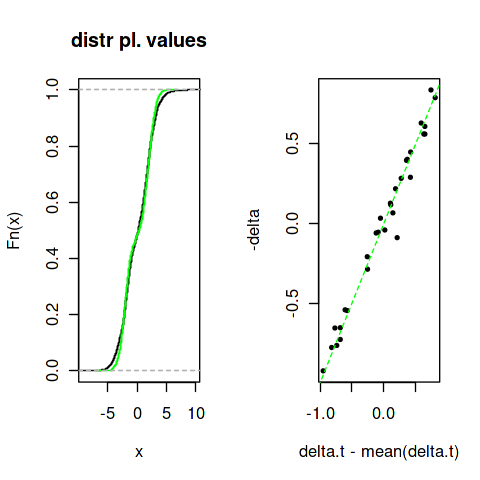

The left panel shows, in green, the empirical cdf of the abilities used to simulate the data. The cdf of the plausible values is plotted on top in black. It will be clear that the plausible value distribution is close. The right panel plots estimated item diffuiculties against the true ones.

## The 2PL

From Rasch to 2PL is a small step. It means adding discrimination parameters $\alpha_i$ for the items. Under a 2PL,
$$P(Y_{pi}=1|\theta_p, \alpha_i,\delta_i)
=\frac{\exp(\alpha_i\theta_p+\delta_i)}{1+\exp(\alpha_i\theta_p+\delta_i)}=F_{pi}(\theta, \alpha_i, \delta_i),$$
where $\alpha_i$ the discrimination parameter of item $i$. As with the Rash model, all FCP distribution are of the same form. Summarizing:
$$\text{Sample $\theta_p$:}
\left\{
\begin{array}{l}
\eta=\theta_p\\
\mathbf{x}=\mathbf{y}_{p.}\\
\mathbf{a}=\boldsymbol{\alpha}_i \\
\mathbf{b}=\boldsymbol{\delta}_i
\end{array} \right. \quad
\text{Sample $\delta_i$:}
\left\{
\begin{array}{l}
\eta=\delta_i\\
\mathbf{x}=\mathbf{y}_{.i}\\
\mathbf{a}=\mathbf{1}_{n_p} \\
\mathbf{b}=\alpha_i \boldsymbol{\theta}
\end{array} \right. \quad
\text{Sample $\alpha_i$:}
\left\{
\begin{array}{l}
\eta=\alpha_i \\
\mathbf{x}=\mathbf{y}_{.i}\\
\mathbf{a}=\boldsymbol{\theta} \\
\mathbf{b}=\delta_i \mathbf{1}_{n_p}
\end{array}
\right.$$

Here is the implementation.

```r
nP=nrow(y); nI=ncol(y)
   # priors
mu.th = 0; sigma.th = 2
mu.b = 0; sigma.b = 0.5
    # start_values
delta=runif(nI,-1,1)
theta=rnorm(nP,mu.th,sigma.th)
alpha=rep(1,nI)

for (iter in 1:50)
{
  init = ifelse(iter<5,1,0)
  theta = sapply(1:nP,function(p) MH_R(y[p,], alpha, delta, theta[p], mu.th, sigma.th, 'normal',init))
  delta = sapply(1:nI,function(i) MH_R(y[,i], rep(1,nP), alpha[i]*theta, delta[i], mu.b, sigma.b,'normal',init))
  alpha = sapply(1:nI,function(i) MH_R(y[,i], theta, rep(delta,nP), alpha[i], 1, 0.5,'normal',init))

      # Identify
  alpha=alpha/alpha[1]
  shift=sum(delta)/sum(alpha)
  delta = delta-shift*alpha

      # Update ability prior
  sigma.th = sqrt(1/rgamma(1,shape=(nP-1)/2,rate=((nP-1)/2)*var(theta)))
  mu.th = rnorm(1,mean(theta),sigma.th/sqrt(nP))
}
```

As before, here are the results when applied to simulated data.

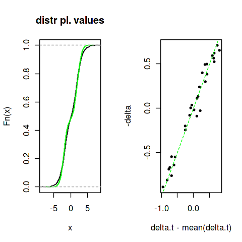

# A Multi-dimensional IRT Model

A bifactor model is a latent structure where each item loads on a general latent trait but there also are group traits explaining additional common variance for item subsets. The general latent variable is what is in common among the items (i.e., the common latent trait approach). This pattern is almost always seen in practice with group traits corresponding to properties of the items that have been introduced deliberately by item writers. Bifactor analysis is particularly valuable to determining the extent to which scores reflect a single variable even when the data are multidimensional. Here we consider a constrained bifactor model.

Consider the following multi-dimensional IRT model
$$\begin{equation}\label{Eq:MD}
P(Y_{pi}=1|\boldsymbol{\theta}_p, \boldsymbol{\lambda},\boldsymbol{\delta})
=\frac{\exp\left(\sum^{n_k}_{k=1} \lambda_k c_{ik} \theta_{pk} +\delta_i\right)}{1+\exp\left(\sum^{n_k}_{k=1} \lambda_k c_{ik} \theta_{pk} +\delta_i\right)}
\end{equation}$$
where the latent ability $\boldsymbol{\theta}_p=(\theta_{p1},\dots, \theta_{pn_k})$ is multidimensional with $1\leq n_k < n_i$ the number of latent dimensions. We consider a confirmatory model where the $c_{ij}$ are known contrasts (or ) and our main interest is in the parameters $\lambda_k>0$ which give the importance of the $k$th factor defined by $\mathbf{c}_{.k}=(c_{1k}, \dots, c_{n_ik})$.

A Gibbs sampler for this model can be build in the same way as before. The difference is that it is slightly more involved to calculate the constants; $\mathbf{a}$, and $\mathbf{b}$. In fact, we would consider doing it in a compiled language like C or C++. Summarizing,
$$\begin{equation*}
\text{$\eta=\delta_i$ $\Rightarrow$}
\left\{
\begin{array}{l}
\mathbf{x}=\mathbf{y}_{.i}\\
\mathbf{a}=\mathbf{1}_{n_p} \\
b_p=\sum_j \lambda_j c_{ij} \theta_{pj}
\end{array}
\right. \quad
\text{$\eta=\theta_{pj}$ $\Rightarrow$}
\left\{
\begin{array}{l}
\mathbf{x}=\mathbf{y}_{p.}\\
\mathbf{a}=\lambda_j \mathbf{c}_{.j} \\
b_i=\delta_i+\sum_{h \neq j} \lambda_h c_{ih} \theta_{ph}
\end{array}
\right.
\end{equation*}$$
When we sample $\lambda_j$, the observations $\mathbf{x}$ comprise the whole data matrix stored as a vector. If we denote by $(ip)$ an index that runs over all $n_i \times n_p$ observations in the same order in which the data matrix is stored as a vector, we obtain:
$$\begin{equation}
a_{(ip)}=c_{ij} \theta_{pj}, \text{ and} \quad b_{(ip)}=\delta_i+\sum_{h \neq j} \lambda_h c_{ih} \theta_{ph}
\end{equation}$$
Note that $a_{(ip)}=0$ for all $i$ where $c_{ij}=0$; that is, for all items that do not load on factor $j$.

A special case of the model is a constrained bi-factor model where the items form *clusters* such that withing each cluster all items have the same factor-loadings. The first dimension is the general factor and $\mathbf{c}_{i1}=1$, for all items $i$. The other dimensions correspond to the cluster-factors with $c_{ij}=1$ if item $i$ belongs to cluster $j$ and $c_{ij}=0$ otherwise, for $j>1$. The loading of factor $j$ is $\lambda_j$ for all items $i$ where $c_{ij}=1$.

The following R function implements the Gibbs sampler.

```r
BIfactor = function(x, C, nIter=100)
{
  nD = ncol(C)
  m=nrow(x)
  n=ncol(x)
  mu.pv=rep(0,nD)
  delta=runif(n,-1,1)
  lambda=rep(1,nD)
  pv=matrix(0,m,nD)
  for (j in 1:nD) pv[,j]=rnorm(m,mu.pv[j],1)

    ### vectors
  a_n=vector("numeric", n)
  b_n=vector("numeric", n)
  a_m=vector("numeric", m)
  b_m=vector("numeric", m)
  a_nm=vector("numeric", n*m)
  b_nm=vector("numeric", n*m)

  store_lambda= matrix(0,nD,nIter)
  store_delta = matrix(0,m,nIter)

  for (iter in 1:nIter)
  {
      init=(iter<2)

        # Update \delta_i
      for (i in 1:n)
      {
          for (p in 1:m)
          {
              b_m[p]=0; a_m[p]=1
              for (j in 1:nD)
              {
                 b_m[p]=b_m[p]+C[i,j]*lambda[j]*pv[p,j]
              }
          }
          delta[i]=MH_R(x[,i], a_m, b_m, delta[i], 0, 1, 'normal', init)
      }
          # Update \theta_{pj}
      for (p in 1:m)
      {
          for (j in 1:nD)
          {
            for (i in 1:n)
            {
                a_n[i]=lambda[j]*C[i,j]
                b_n[i]=delta[i]
                for (h in 1:nD)
                {
                    if (h!=j) b_n[i]=b_n[i]+lambda[h]*C[i,h]*pv[p,h]
                }
            }
          pv[p,j]=MH_R(x[p,],a_n, b_n, pv[p,j], mu.pv[j], 1,'normal', init)
        }
      }

      for (j in 1:nD)
      {
        ip=0
        for (i in 1:n)
        {
          for (p in 1:m)
          {
            ip=ip+1
            b_nm[ip]=delta[i]
            a_nm[ip]=C[i,j]*pv[p,j]
            for (h in 1:nD)
            {
              if (h!=j) b_nm[ip]=b_nm[ip]+lambda[h]*C[i,h]*pv[p,h]
            }
          }
        }
        lambda[j]=MH_R(as.vector(x),a_nm,b_nm,lambda[j],1,2,'exp', init)
      }

      delta = delta - mean(delta)

      ## update prior plausible values
      for (j in 1:nD){
        pv[,j] = pv[,j]/sd(pv[,j])
        mu.pv[j] = rnorm(1,mean(pv[,j]),1/sqrt(m))
      }

      store_lambda[,iter] = lambda
      store_delta[,iter] = delta
  }
  return(list(delta=store_delta, lambda=store_lambda))
}
```

Note that we have standardized the latent variables for identification.

For illustration, we use this function to analyze the responses of $500$ first year psychology students to $240$ personality items developed to measure individual differences in five personality traits known as ``the big five":

- N: Neuroticism. Sometimes referred to as emotional instability, it is the tendency to experience negative emotions, such as anger, anxiety, or depression.
- E: Extraversion. Extraversion is characterized by breadth of activities (as opposed to depth).
- A: Agreeableness. A general concern for social harmony.
- O: Openness to experience. A general appreciation for art, emotion, adventure, unusual ideas, imagination, curiosity, and variety of experience.
- C: Conscientiousness. A tendency to display self-discipline, act dutifully, and strive for achievement against measures or outside expectations.

These traits form the clusters. The data are taken from the *qgraph* package and dichotomized with one if a respondent felt a description applied to her (4 and 5), and a zero if not. We sort the items such that items that measure the same trait are grouped together.

To illustrate that the constrained bi-factor model reproduces, in a highly parsimonious way, the blocked pattern typically seen in the observed correlations we run this routine for 20 iterations and plot an image the correlations implied by the model at the 20th iteration. We see that, starting from the first iterations, the model pick up the structure in the data.

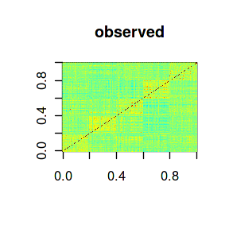

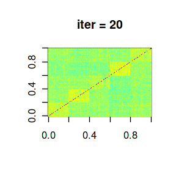

Note that the implied correlations are calculated by sampling data using the parameters sampled in the 20th iteration. To this aim, we have used the *rMIRT_R* function provided here:

```r
rMIRT_R = function(theta, alpha, delta)
{
  nP = nrow(theta)
  nI = nrow(alpha)
  x=matrix(NA,nP,nI)
  for (i in 1:nI)
  {
        x[,i] = 1*(rlogis(nP,0,1)<=(theta%*%alpha[i,]+delta[i]))
  }
  return(x)
}
```

If we run a thousand iterations we find that this test is clearly multi-dimensional. As judged from the factor loadings, the most important dimension is *neuroticism* (``worrying that thing go wrong") with a posterior mean of $0.976$ with variance $0.002$. The first dimension, corresponding to the sum of the (dichotomized) responses was least important; the posterior mean of $\lambda_1$ was $0.32$ with a variance of $0.0008$. A priori, the factors have been assumed uncorrelated but posterior correlations among the plausible values show that *neuroticism* correlates negatively with *extraversion* and *conscientiousness* while other correlations are close to zero.

# Logistic Regression

## Introduction

For a binary variable Y and an explanatory variable X, let
$$\pi(x; \alpha, \beta) = P(Y=1|x) = \frac{e^{\alpha+\beta x}}{1+e^{\alpha+\beta x}}$$
With a sample of N, the likelihood is:
$$\prod_p \pi^{y_p}(x_p; \alpha, \beta)(1-\pi(x_p; \alpha, \beta))^{1-y_p}$$
is of the right form.

We will illustrate this using the horseshoe crab data – analyzed extensively by Agresti and available in the **glm2** package. For this particular purpose we use the presence of absence of a satellite as the outcome variable.

```r
library(glm2)
data("crabs")
dat = data.frame(y=1*(crabs$Satellites>0), x=crabs$Width-mean(crabs$Width))
```

Note that it is important to center the predictor which greatly diminishes auto-correlation. It means that the intercept parameter becomes the logit as $x=\bar{x}$; that is, $\pi(\bar{x})=\exp(\alpha)/(1+\exp(\alpha))$.

Here is a script for a Gibbs sampler.

```r
  N = length(dat$y)
  # Center the data
  mean_x = mean(dat$x)
  dat$x = dat$x-mean_x
    # start_values
  tr_alpha= NULL
  tr_beta = NULL
  alpha=0
  beta=1
  for (iter in 1:nIter)
  {
      init = ifelse(iter<20,1,0)
      alpha= MH_R(dat$y, rep(1,N), beta*dat$x, alpha, 0, 4, 'normal', init)
      beta = MH_R(dat$y, dat$x, rep(alpha,N), beta, -1, 0.5, 'normal', init)
        # store the sampled values
      tr_alpha = c(tr_alpha,alpha)
      tr_beta = c(tr_beta,beta)
  }
    # Undo the effect of centering
  tr_alpha = tr_alpha - tr_beta*mean_x
  dat$x = dat$x+mean_x
```

To illustrate, we use this script and plot the logistic regression curve; with the parameters set at their posterior means in black and a few iterations in red.

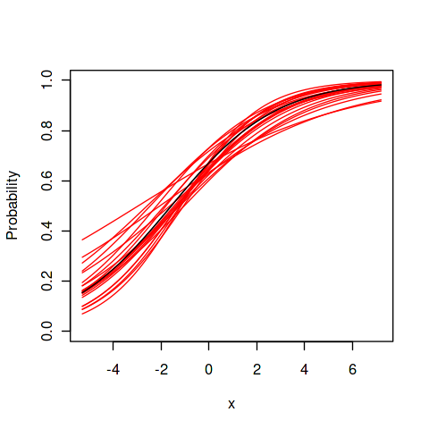

## Bayesian Lasso

A Laplace prior can be used to enforce regression coefficients to be zero. It has a parameter $\lambda$ such that the larger $\lambda$, the more prior mass on zero. Here some plots of the density function to illustrate.

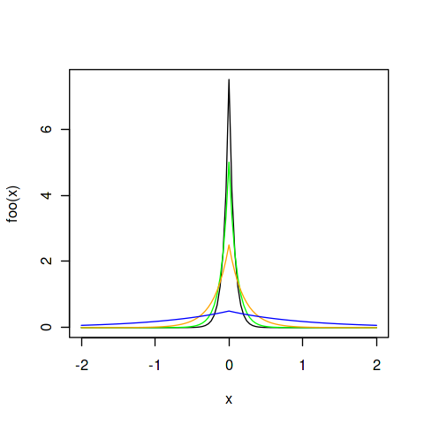

To implement the Laplace prior, we need to adapt the basic functions. We are quite sure the reader understands how but we provide the details here for completeness, showing only what changes.

```r
rPrior <- function(n, mu, sigma, prior)
{
  ## ... ##
  if (prior == "Laplace") out = rlaplace(n, mu, sigma)
  ## ... ##
}

Prior_MH <- function(z, j, y, current, mu, sigma, prior)
{
   ## ... ##
  if (prior=="Laplace")
  {
        c_4=dlaplace(z[j], mu=0, sigma, log=TRUE)
        c_5=dlaplace(current, mu=0, sigma, log = TRUE)
        c_6=plaplace(current, mu=0, sigma, lower.tail=y[n],log.p = TRUE)
        c_7=plaplace(z[j], mu=0, sigma, lower.tail=y[n],log.p = TRUE)
  }
  # ... #
}

MH_R = function(x, a, b, current, mu, sigma, prior=c("normal", "exp", "Laplace"), accept_all=FALSE)
{
  # ... #
}
```

If the parameter of the Laplace prior is given a hyper-prior, we may estimate its value. More specifically, we give $\lambda^{-1}$ a Gamma($\alpha$,$\beta$) hyperprior, its CP distribution is Gamma($\alpha+m$,$\beta+\sum_j |\beta_j|$). The following script provides a straightforward implementation to do this logistic regression with or without a Bayesian Lasso.

```r
GibbsLogistic_R = function(dat, out=1, covariates, lasso=FALSE, lambda=NULL, nIter = 1000, center=TRUE)
{
    dat = cbind(dat,1)
    covariates = c(covariates,ncol(dat))
    nb = length(covariates)
    est_lambda = is.null(lambda)
    tr_beta = matrix(0,nb,nIter)
    if (est_lambda){
      tr_lambda = rep(0,nIter)
    }else
    {
      tr_lambda = rep(lambda,nIter)
    }
    est_lambda = is.null(lambda)

    M=10

        # centre covariates
    if (center)
    {
      mean_x = colMeans(dat)
      for (i in covariates[1:(nb-1)]) dat[,i] = dat[,i]-mean_x[i]
    }

    if (lasso&est_lambda) lambda = rgamma(1,3,1)

    beta=runif(nb,-1,1)
    for (iter in 1:nIter)
    {
        for (i in 1:(nb-1))
        {
            b = as.matrix(dat[,covariates[-i]])%*%beta[-i]
            beta[i] = ifelse(lasso,
              MH_R(dat[,out], dat[,covariates[i]], b, beta[i], 0, 1/lambda,
                                prior = "Laplace",
                                accept_all = ifelse(iter<M,1,0)),
              MH_R(dat[,out], dat[,covariates[i]], b, beta[i], 0, 2,
                                prior = 'normal',
                                accept_all = ifelse(iter<M,1,0)))
        }
        b = as.matrix(dat[,covariates[-nb]])%*%beta[-nb]
        beta[nb] = MH_R(dat[,out], dat[,covariates[nb]], b, beta[nb], 0, 4,
                                prior = 'normal',
                                accept_all = ifelse(iter<M,1,0))

        if (lasso&est_lambda)
        {
          lambda = rgamma(1,shape=3+nb-1,rate=1+sum(abs(beta)[1:(nb-1)]))
          tr_lambda[iter] = lambda
        }

        tr_beta[,iter] = beta
    }

    if (center){
      for (i in 1:(nb-1)) tr_beta[nb,] = tr_beta[nb,] - tr_beta[i,]*mean_x[covariates[i]]
    }
    return(list(alpha=tr_beta[nb,], beta=tr_beta[1:(nb-1),], lambda=tr_lambda))
}
```

## Application to the GLOW500 data

The Global Longitudinal Study of Osteoporosis in Women (GLOW) is an international study of osteoporosis in women over 55 years of age being coordinated at the Center for Outcomes Research (COR) at the University of Massachusetts/Worcester. Data used here come from six sites in the United States and include a few selected potential risk factors for fracture from the baseline questionnaire. The major goals of the study are to use the data to provide insights into the management of fracture risk, patient experience with prevention and treatment of fractures and distribution of risk factors among older women on an international scale over the follow up period.

The outcome variable is any fracture in the first year of follow up. We use the $n=500$ set available from the **aplore3** package. We deleted raterrisk3 leaving 5 predictors. We calculated the posterior median of each of the coefficients for a sequence of values for $\lambda$. Then, we estimate the value of $\lambda$. The results can be shown in a coefficient plot. The posterior estimate of $\lambda$ is indicated with a dashed vertical line.

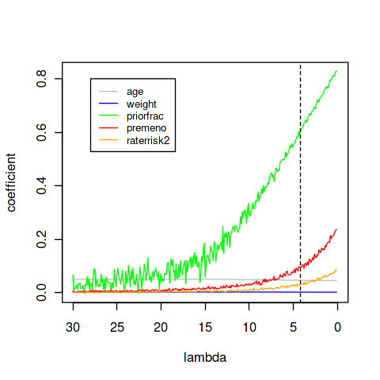

Note that this Gibbs sampler is not the most efficient way to do this type of analysis. The sampling of coefficients must be done sequentially and cannot be done parallel with multiple cores.